# Cereal_Analysis

Siva Bulusu

October 5, 2019

## Problem Statement

The data file labeled Cereal has the following information As part of a study of consumer consideration of ready-to-eat cereals sponsored by Kellogg Australia, Roberts and Lattin (1991) surveyed consumers regarding their perceptions of their favorite brands of cereals. Each respondent was asked to evaluate three preferred brands on each of 25 different attributes. Respondents used a five point likert scale to indicate the extent to which each brand possessed the given attribute. For the purpose of this assignment, a subset of the data collected by Roberts and Lattin, reflecting the evaluations of the 12 most frequently cirted cereal brands in the sample (in the original study, a total of 40 different brands were evaluated by 121 respondents, but the majority of brands were rated by only a small number of consumers). The 25 attributes and 12 brands are listed below

## Cereal Brands:

All Bran,Cerola Muesli,Just Right,Kellogg’s corn falkes,Komplete,Nutrigrain,Purina Muesli,Rice Bubbles,Special K,Sustain,Vitabrit,Weetbix

## Attributes

Filling,Natural,Fibre,Sweet,Easy,Salt,Satisfying,Energy,Fun,Kids,Soggy,Economical,Health,Family,Calories,Plain,Crisp,Regular,Sugar,Fruit,Process,Quality,Treat,Boring,Nutritious

In total 116 respondents provided 235 observations of the 12 selected brands. How do you characterize the consideration behavior of the 12 selected brands? Analyze and interpret your results using factor analysis.

## Solution

Include required libraries

```r
library(psych)
```

```r
library(corrplot)
library(nFactors)
library(GPArotation)
```

Import data and have a look

```r
cerealdata <- read.csv("D:/SivaBulusu/Cereal_FA/Dataset_Cereal.csv", header = TRUE)
View(cerealdata)
```

Check for structure of data. First column Cereals is factor and rest all the columns are integers which is desired.

```r
str(cerealdata)
```

```
## 'data.frame':    235 obs. of  26 variables:
##  $ Cereals   : Factor w/ 12 levels "AllBran","CMuesli",..: 12 9 9 2 3 8 9 9 8 3 ...
##  $ Filling   : int  5 1 5 5 4 4 4 4 4 4 ...
##  $ Natural   : int  5 2 4 5 5 4 4 3 3 3 ...
##  $ Fibre     : int  5 2 5 5 3 4 3 3 3 3 ...
##  $ Sweet     : int  1 1 5 3 2 2 2 2 2 2 ...
##  $ Easy      : int  2 5 5 5 5 5 5 5 5 5 ...
##  $ Salt      : int  1 2 3 2 2 2 1 1 1 1 ...
##  $ Satisfying: int  5 5 5 5 5 5 5 5 5 5 ...
##  $ Energy    : int  4 1 5 5 4 4 5 4 4 4 ...
##  $ Fun       : int  1 1 5 5 5 5 5 4 4 4 ...
##  $ Kids      : int  4 5 5 5 5 5 5 5 5 5 ...
##  $ Soggy     : int  5 3 3 3 1 1 1 1 1 1 ...
##  $ Economical: int  5 5 3 3 5 5 5 3 3 3 ...
##  $ Health    : int  5 2 5 5 5 4 5 4 4 4 ...
##  $ Family    : int  5 5 5 5 3 5 5 5 5 5 ...
##  $ Calories  : int  1 1 1 1 3 3 3 2 2 2 ...
##  $ Plain     : int  3 5 1 1 1 1 1 3 3 3 ...
##  $ Crisp     : int  1 5 5 1 5 5 5 4 4 4 ...
##  $ Regular   : int  4 1 4 4 3 3 3 4 4 4 ...
##  $ Sugar     : int  1 2 3 2 1 2 2 1 1 1 ...
##  $ Fruit     : int  1 1 1 5 1 1 1 1 1 1 ...
##  $ Process   : int  3 5 2 2 3 3 3 2 2 2 ...
##  $ Quality   : int  5 2 5 5 5 5 5 4 4 4 ...
##  $ Treat     : int  1 1 4 5 5 5 5 2 2 2 ...
##  $ Boring    : int  1 1 1 1 1 1 1 1 1 1 ...
##  $ Nutritious: int  5 3 5 5 4 4 4 3 3 3 ...
```

Check for missing values in the dataset. There are no missing values in any of the columns.

```r
sapply(cerealdata,function(x){sum(is.na(x))})
```

```
##    Cereals    Filling    Natural      Fibre      Sweet       Easy
##          0          0          0          0          0          0
##       Salt Satisfying     Energy        Fun       Kids      Soggy
##          0          0          0          0          0          0
## Economical     Health     Family   Calories      Plain      Crisp
##          0          0          0          0          0          0
##    Regular      Sugar      Fruit    Process    Quality      Treat
##          0          0          0          0          0          0
##     Boring Nutritious
##          0          0
```

View Summary of data. There are some values in the data which have a rating greater than 5. This should not be the case as the respondents used a five point likert scale. Ratings should be from 1 to 5. Other numbers are not allowed. For the numbers which are higher than 5 can be filled by 5 assuming that the respondent wanted to give higher rating for that attribute.

```r
summary(cerealdata)
```

```
##         Cereals      Filling         Natural          Fibre
##  CornFlakes :27   Min.   :1.000   Min.   :1.000   Min.   :1.000
##  Weetabix   :27   1st Qu.:3.000   1st Qu.:3.000   1st Qu.:3.000
##  Vitabrit   :25   Median :4.000   Median :4.000   Median :4.000
##  NutriGrain :24   Mean   :3.881   Mean   :3.783   Mean   :3.528
##  SpecialK   :23   3rd Qu.:4.500   3rd Qu.:4.000   3rd Qu.:4.000
##  RiceBubbles:21   Max.   :5.000   Max.   :5.000   Max.   :5.000
##  (Other)    :88
##      Sweet            Easy            Salt         Satisfying
##  Min.   :1.000   Min.   :1.000   Min.   :1.000   Min.   :2.000
##  1st Qu.:2.000   1st Qu.:4.000   1st Qu.:1.000   1st Qu.:3.000
##  Median :2.000   Median :5.000   Median :2.000   Median :4.000
##  Mean   :2.506   Mean   :4.532   Mean   :1.991   Mean   :4.004
##  3rd Qu.:3.000   3rd Qu.:5.000   3rd Qu.:3.000   3rd Qu.:5.000
##  Max.   :5.000   Max.   :6.000   Max.   :4.000   Max.   :6.000
##
##      Energy           Fun             Kids           Soggy
##  Min.   :1.000   Min.   :1.000   Min.   :1.000   Min.   :1.000
##  1st Qu.:3.000   1st Qu.:2.000   1st Qu.:3.000   1st Qu.:1.000
##  Median :4.000   Median :2.000   Median :4.000   Median :2.000
##  Mean   :3.643   Mean   :2.617   Mean   :3.843   Mean   :2.255
##  3rd Qu.:4.000   3rd Qu.:3.000   3rd Qu.:5.000   3rd Qu.:3.000
##  Max.   :5.000   Max.   :5.000   Max.   :6.000   Max.   :5.000
##
##    Economical        Health          Family         Calories
##  Min.   :1.000   Min.   :1.000   Min.   :1.000   Min.   :1.000
##  1st Qu.:3.000   1st Qu.:3.000   1st Qu.:3.000   1st Qu.:2.000
##  Median :3.000   Median :4.000   Median :4.000   Median :3.000
##  Mean   :3.217   Mean   :3.809   Mean   :3.877   Mean   :2.702
##  3rd Qu.:4.000   3rd Qu.:4.000   3rd Qu.:5.000   3rd Qu.:3.000
##  Max.   :5.000   Max.   :5.000   Max.   :6.000   Max.   :5.000
##
##      Plain           Crisp          Regular          Sugar
##  Min.   :1.000   Min.   :1.000   Min.   :1.000   Min.   :1.000
##  1st Qu.:1.000   1st Qu.:2.000   1st Qu.:2.000   1st Qu.:1.000
##  Median :2.000   Median :3.000   Median :3.000   Median :2.000
##  Mean   :2.268   Mean   :3.204   Mean   :3.072   Mean   :2.145
##  3rd Qu.:3.000   3rd Qu.:4.000   3rd Qu.:4.000   3rd Qu.:3.000
##  Max.   :5.000   Max.   :6.000   Max.   :5.000   Max.   :5.000
##
##      Fruit          Process         Quality          Treat
##  Min.   :1.000   Min.   :1.000   Min.   :1.000   Min.   :1.00
##  1st Qu.:1.000   1st Qu.:2.000   1st Qu.:3.000   1st Qu.:2.00
##  Median :1.000   Median :3.000   Median :4.000   Median :3.00
##  Mean   :1.694   Mean   :2.936   Mean   :3.694   Mean   :2.63
##  3rd Qu.:3.000   3rd Qu.:4.000   3rd Qu.:4.000   3rd Qu.:3.00
##  Max.   :5.000   Max.   :6.000   Max.   :5.000   Max.   :6.00
##
##      Boring       Nutritious
##  Min.   :1.00   Min.   :1.000
##  1st Qu.:1.00   1st Qu.:3.000
##  Median :2.00   Median :4.000
##  Mean   :1.83   Mean   :3.664
##  3rd Qu.:2.00   3rd Qu.:4.000
##  Max.   :5.00   Max.   :5.000
##
```

Replace 6 with 5 in the data and recheck summary

```r
cerealdata[cerealdata==6]<-5
summary(cerealdata)
```

```
##         Cereals      Filling         Natural          Fibre
##  CornFlakes :27   Min.   :1.000   Min.   :1.000   Min.   :1.000
##  Weetabix   :27   1st Qu.:3.000   1st Qu.:3.000   1st Qu.:3.000
##  Vitabrit   :25   Median :4.000   Median :4.000   Median :4.000
##  NutriGrain :24   Mean   :3.881   Mean   :3.783   Mean   :3.528
##  SpecialK   :23   3rd Qu.:4.500   3rd Qu.:4.000   3rd Qu.:4.000
##  RiceBubbles:21   Max.   :5.000   Max.   :5.000   Max.   :5.000
##  (Other)    :88
##      Sweet            Easy            Salt         Satisfying
##  Min.   :1.000   Min.   :1.000   Min.   :1.000   Min.   :2
##  1st Qu.:2.000   1st Qu.:4.000   1st Qu.:1.000   1st Qu.:3
##  Median :2.000   Median :5.000   Median :2.000   Median :4
##  Mean   :2.506   Mean   :4.528   Mean   :1.991   Mean   :4
##  3rd Qu.:3.000   3rd Qu.:5.000   3rd Qu.:3.000   3rd Qu.:5
##  Max.   :5.000   Max.   :5.000   Max.   :4.000   Max.   :5
##
##      Energy           Fun             Kids           Soggy
##  Min.   :1.000   Min.   :1.000   Min.   :1.000   Min.   :1.000
##  1st Qu.:3.000   1st Qu.:2.000   1st Qu.:3.000   1st Qu.:1.000
##  Median :4.000   Median :2.000   Median :4.000   Median :2.000
##  Mean   :3.643   Mean   :2.617   Mean   :3.838   Mean   :2.255
##  3rd Qu.:4.000   3rd Qu.:3.000   3rd Qu.:5.000   3rd Qu.:3.000
##  Max.   :5.000   Max.   :5.000   Max.   :5.000   Max.   :5.000
##
##    Economical        Health          Family         Calories
##  Min.   :1.000   Min.   :1.000   Min.   :1.000   Min.   :1.000
##  1st Qu.:3.000   1st Qu.:3.000   1st Qu.:3.000   1st Qu.:2.000
##  Median :3.000   Median :4.000   Median :4.000   Median :3.000
##  Mean   :3.217   Mean   :3.809   Mean   :3.872   Mean   :2.702
##  3rd Qu.:4.000   3rd Qu.:4.000   3rd Qu.:5.000   3rd Qu.:3.000
##  Max.   :5.000   Max.   :5.000   Max.   :5.000   Max.   :5.000
##
##      Plain           Crisp        Regular          Sugar
##  Min.   :1.000   Min.   :1.0   Min.   :1.000   Min.   :1.000
##  1st Qu.:1.000   1st Qu.:2.0   1st Qu.:2.000   1st Qu.:1.000
##  Median :2.000   Median :3.0   Median :3.000   Median :2.000
##  Mean   :2.268   Mean   :3.2   Mean   :3.072   Mean   :2.145
##  3rd Qu.:3.000   3rd Qu.:4.0   3rd Qu.:4.000   3rd Qu.:3.000
##  Max.   :5.000   Max.   :5.0   Max.   :5.000   Max.   :5.000
##
##      Fruit          Process         Quality          Treat
##  Min.   :1.000   Min.   :1.000   Min.   :1.000   Min.   :1.000
##  1st Qu.:1.000   1st Qu.:2.000   1st Qu.:3.000   1st Qu.:2.000
##  Median :1.000   Median :3.000   Median :4.000   Median :3.000
##  Mean   :1.694   Mean   :2.932   Mean   :3.694   Mean   :2.626
##  3rd Qu.:3.000   3rd Qu.:4.000   3rd Qu.:4.000   3rd Qu.:3.000
##  Max.   :5.000   Max.   :5.000   Max.   :5.000   Max.   :5.000
##
##      Boring       Nutritious
##  Min.   :1.00   Min.   :1.000
##  1st Qu.:1.00   1st Qu.:3.000
##  Median :2.00   Median :4.000
##  Mean   :1.83   Mean   :3.664
##  3rd Qu.:2.00   3rd Qu.:4.000
##  Max.   :5.00   Max.   :5.000
##
```

Check if Dimensionality Reduction is possible in this case using Bartlett Test H0: Correlation matrix is an identity matrix which means here is no scope for dimensionality reduction. H1: Dimensionality Reduction is possible.

```r
#Get matrix of scores rounded to 2 digits after decimal
cereal_Matrix <- cor(cerealdata[,-1])
cereal_Matrix <- round(cereal_Matrix, 2)
cereal_Matrix
```

```
##            Filling Natural Fibre Sweet  Easy  Salt Satisfying Energy   Fun
## Filling       1.00    0.54  0.55  0.19  0.24 -0.04       0.65   0.64  0.27
## Natural       0.54    1.00  0.65 -0.09  0.23 -0.22       0.47   0.49  0.08
## Fibre         0.55    0.65  1.00 -0.04  0.18 -0.17       0.41   0.50  0.06
## Sweet         0.19   -0.09 -0.04  1.00  0.12  0.44       0.18   0.18  0.33
## Easy          0.24    0.23  0.18  0.12  1.00  0.01       0.35   0.18  0.24
## Salt         -0.04   -0.22 -0.17  0.44  0.01  1.00      -0.01  -0.07  0.03
## Satisfying    0.65    0.47  0.41  0.18  0.35 -0.01       1.00   0.60  0.35
## Energy        0.64    0.49  0.50  0.18  0.18 -0.07       0.60   1.00  0.35
## Fun           0.27    0.08  0.06  0.33  0.24  0.03       0.35   0.35  1.00
## Kids          0.16    0.06 -0.09  0.12  0.24  0.02       0.30   0.13  0.34
## Soggy        -0.06    0.07 -0.04 -0.08 -0.01  0.02      -0.01  -0.05 -0.10
## Economical    0.05    0.10 -0.03 -0.24  0.09 -0.13       0.21   0.03  0.04
## Health        0.55    0.69  0.68 -0.12  0.20 -0.23       0.52   0.52  0.10
## Family        0.23    0.11 -0.01  0.04  0.23 -0.09       0.35   0.19  0.35
## Calories      0.05   -0.16 -0.19  0.47 -0.02  0.44       0.01   0.03  0.11
## Plain        -0.25   -0.14 -0.12 -0.29  0.02  0.02      -0.18  -0.26 -0.32
## Crisp         0.13    0.02  0.05  0.26  0.24  0.10       0.26   0.25  0.40
## Regular       0.42    0.42  0.65 -0.03  0.11 -0.16       0.33   0.39  0.14
## Sugar        -0.08   -0.32 -0.23  0.65 -0.02  0.59      -0.09  -0.09  0.17
## Fruit         0.26    0.30  0.29  0.35  0.04  0.03       0.25   0.27  0.25
## Process      -0.23   -0.31 -0.19  0.11 -0.07  0.30      -0.19  -0.10 -0.01
## Quality       0.44    0.58  0.51 -0.08  0.16 -0.22       0.47   0.46  0.22
## Treat         0.34    0.17  0.14  0.37  0.18  0.12       0.37   0.32  0.58
## Boring       -0.18   -0.22 -0.10 -0.20 -0.17  0.11      -0.32  -0.22 -0.30
## Nutritious    0.53    0.65  0.71 -0.05  0.20 -0.16       0.50   0.54  0.16
##             Kids Soggy Economical Health Family Calories Plain Crisp
## Filling     0.16 -0.06       0.05   0.55   0.23     0.05 -0.25  0.13
## Natural     0.06  0.07       0.10   0.69   0.11    -0.16 -0.14  0.02
## Fibre      -0.09 -0.04      -0.03   0.68  -0.01    -0.19 -0.12  0.05
## Sweet       0.12 -0.08      -0.24  -0.12   0.04     0.47 -0.29  0.26
## Easy        0.24 -0.01       0.09   0.20   0.23    -0.02  0.02  0.24
## Salt        0.02  0.02      -0.13  -0.23  -0.09     0.44  0.02  0.10
## Satisfying  0.30 -0.01       0.21   0.52   0.35     0.01 -0.18  0.26
## Energy      0.13 -0.05       0.03   0.52   0.19     0.03 -0.26  0.25
## Fun         0.34 -0.10       0.04   0.10   0.35     0.11 -0.32  0.40
## Kids        1.00  0.09       0.30  -0.01   0.72     0.01  0.03  0.29
## Soggy       0.09  1.00       0.12   0.01   0.08    -0.08  0.35 -0.34
## Economical  0.30  0.12       1.00   0.19   0.23    -0.21  0.23  0.09
## Health     -0.01  0.01       0.19   1.00   0.08    -0.31 -0.10  0.08
```

[output cut: 23 more lines]

```
## Soggy        -0.14 -0.09 -0.14    0.06   -0.03 -0.26   0.23       0.03
## Economical    0.08 -0.29 -0.34   -0.13    0.22 -0.04  -0.02       0.13
## Health        0.54 -0.38  0.27   -0.29    0.69  0.22  -0.23       0.76
## Family        0.04 -0.06 -0.13   -0.03    0.24  0.29  -0.25       0.09
## Calories     -0.16  0.53  0.13    0.27   -0.20  0.19  -0.03      -0.23
## Plain        -0.08 -0.15 -0.34    0.12   -0.23 -0.43   0.33      -0.14
## Crisp         0.13  0.16  0.09    0.01    0.13  0.46  -0.33       0.10
## Regular       1.00 -0.09  0.25   -0.15    0.44  0.17  -0.09       0.57
## Sugar        -0.09  1.00  0.15    0.37   -0.26  0.21   0.00      -0.27
## Fruit         0.25  0.15  1.00   -0.14    0.16  0.31  -0.26       0.31
## Process      -0.15  0.37 -0.14    1.00   -0.19  0.02   0.17      -0.29
## Quality       0.44 -0.26  0.16   -0.19    1.00  0.33  -0.28       0.66
## Treat         0.17  0.21  0.31    0.02    0.33  1.00  -0.36       0.25
## Boring       -0.09  0.00 -0.26    0.17   -0.28 -0.36   1.00      -0.17
## Nutritious    0.57 -0.27  0.31   -0.29    0.66  0.25  -0.17       1.00
```

```r
#Perform the Bartlett Test
cereal_Bartlett <- cortest.bartlett(cereal_Matrix, n = nrow(cerealdata))
cereal_Bartlett
```

```
## $chisq
## [1] 2878.65
##
## $p.value
## [1] 0
##
## $df
## [1] 300
```

The p-value is zero which is <.001 So, the null hypothesis is rejected. Dimensionality Reduction is possible in this case.

Get scale values as matrix and verify correlations.

```r
#Verify the corelation among the variables
cereal_fa <- as.matrix(cerealdata[,2:26])
cor(cereal_fa)
```

```
##                Filling     Natural        Fibre       Sweet         Easy
## Filling     1.00000000  0.53968982  0.552003065  0.19040004  0.237430844
## Natural     0.53968982  1.00000000  0.652289828 -0.09094192  0.231200127
## Fibre       0.55200307  0.65228983  1.000000000 -0.03739830  0.175859374
## Sweet       0.19040004 -0.09094192 -0.037398300  1.00000000  0.124736166
## Easy        0.23743084  0.23120013  0.175859374  0.12473617  1.000000000
## Salt       -0.03626646 -0.21687200 -0.174887993  0.44399118  0.013718595
## Satisfying  0.65415162  0.46649207  0.414854460  0.17953203  0.351409453
## Energy      0.63675882  0.49354159  0.503730689  0.18496133  0.181689577
## Fun         0.26521397  0.08190321  0.062730827  0.32722313  0.239504083
## Kids        0.16032166  0.05971495 -0.093404569  0.11908175  0.242728223
## Soggy      -0.05988555  0.06839973 -0.041667404 -0.08375192 -0.007683385
## Economical  0.05194244  0.10316137 -0.033965332 -0.23981376  0.089328985
## Health      0.54706871  0.68809770  0.683983690 -0.11562213  0.204213278
## Family      0.23367398  0.10674234 -0.008412267  0.03853504  0.225122821
## Calories    0.04721422 -0.16167366 -0.186542023  0.46731243 -0.022805607
## Plain      -0.25064803 -0.13851302 -0.122845902 -0.28955897  0.019140316
## Crisp       0.12687526  0.02080611  0.050527459  0.25981733  0.240631080
## Regular     0.42049880  0.41763842  0.648375681 -0.02518025  0.106329931
## Sugar      -0.07851945 -0.31680448 -0.225567250  0.64838267 -0.015639984
## Fruit       0.26116604  0.30015027  0.293141065  0.34650542  0.035884483
## Process    -0.23419509 -0.30805266 -0.194892706  0.11450985 -0.066393291
## Quality     0.44321697  0.57909956  0.513193764 -0.07754712  0.164648484
## Treat       0.33983991  0.16989309  0.142593245  0.37467405  0.184731541
## Boring     -0.17785084 -0.21758679 -0.099258673 -0.20033406 -0.169705127
## Nutritious  0.52621459  0.65072607  0.713064954 -0.04716005  0.204448721
##                   Salt   Satisfying      Energy          Fun         Kids
## Filling    -0.03626646  0.654151625  0.63675882  0.265213973  0.160321662
## Natural    -0.21687200  0.466492067  0.49354159  0.081903207  0.059714946
## Fibre      -0.17488799  0.414854460  0.50373069  0.062730827 -0.093404569
## Sweet       0.44399118  0.179532033  0.18496133  0.327223134  0.119081748
## Easy        0.01371860  0.351409453  0.18168958  0.239504083  0.242728223
## Salt        1.00000000 -0.012745988 -0.06713581  0.033474536  0.024483803
## Satisfying -0.01274599  1.000000000  0.60343285  0.348331252  0.302769921
## Energy     -0.06713581  0.603432845  1.00000000  0.350327368  0.129792406
## Fun         0.03347454  0.348331252  0.35032737  1.000000000  0.344943414
## Kids        0.02448380  0.302769921  0.12979241  0.344943414  1.000000000
## Soggy       0.02359707 -0.013261427 -0.04592438 -0.098754958  0.088859520
## Economical -0.12590486  0.212175296  0.02641362  0.040700477  0.303934597
## Health     -0.22837678  0.522089653  0.52424330  0.100955593 -0.013620606
```

[output cut: 75 more lines]

```
## Soggy       0.059960688 -0.02980861 -0.25608689  0.226885825  0.03278639
## Economical -0.129109427  0.21549364 -0.04241349 -0.021378353  0.12902808
## Health     -0.292763907  0.68630485  0.21520709 -0.228589063  0.75761480
## Family     -0.027407092  0.23689399  0.29090532 -0.249748195  0.09103594
## Calories    0.271275078 -0.20135015  0.18994993 -0.027015687 -0.22634007
## Plain       0.115074182 -0.22690816 -0.43243767  0.330525544 -0.14491592
## Crisp       0.010010306  0.13014529  0.46023136 -0.326409963  0.10308733
## Regular    -0.150151681  0.44147633  0.16807989 -0.094697872  0.56777612
## Sugar       0.365692112 -0.26338943  0.21271505 -0.000921067 -0.27463739
## Fruit      -0.142462009  0.16460384  0.31404638 -0.260061699  0.30605745
## Process     1.000000000 -0.19001149  0.01515335  0.172489361 -0.28600488
## Quality    -0.190011494  1.00000000  0.33178455 -0.284256014  0.65983453
## Treat       0.015153345  0.33178455  1.00000000 -0.362789133  0.24507215
## Boring      0.172489361 -0.28425601 -0.36278913  1.000000000 -0.17027548
## Nutritious -0.286004881  0.65983453  0.24507215 -0.170275481  1.00000000
```

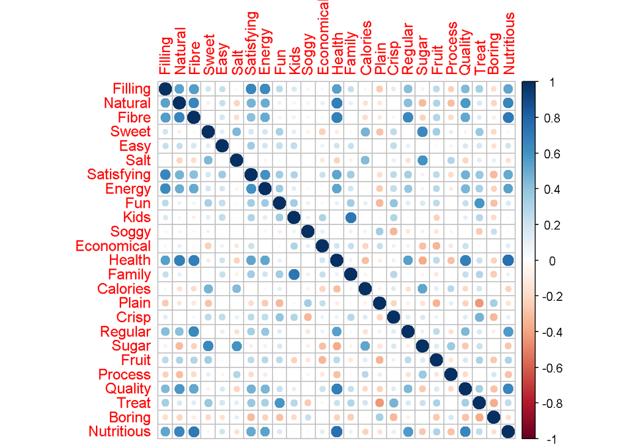

```r
corrplot(cor(cereal_fa))
```

Check for eigen values and decide on number of factors

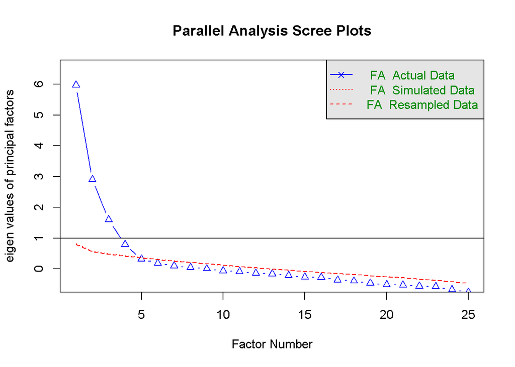

```
## Parallel analysis suggests that the number of factors =  4  and the number of components =  NA
```

```r
#Check for eigen values and decide on number of factors
numFactors <- fa.parallel(cerealdata[,-1], fm="ml", fa="fa")
```

From the graph 3 points have eigen value greater than one. The 4th point is almost near 1(>0.79). So, considering 4 factors to be on safer side.

Check for eigen values and decide on number of factors

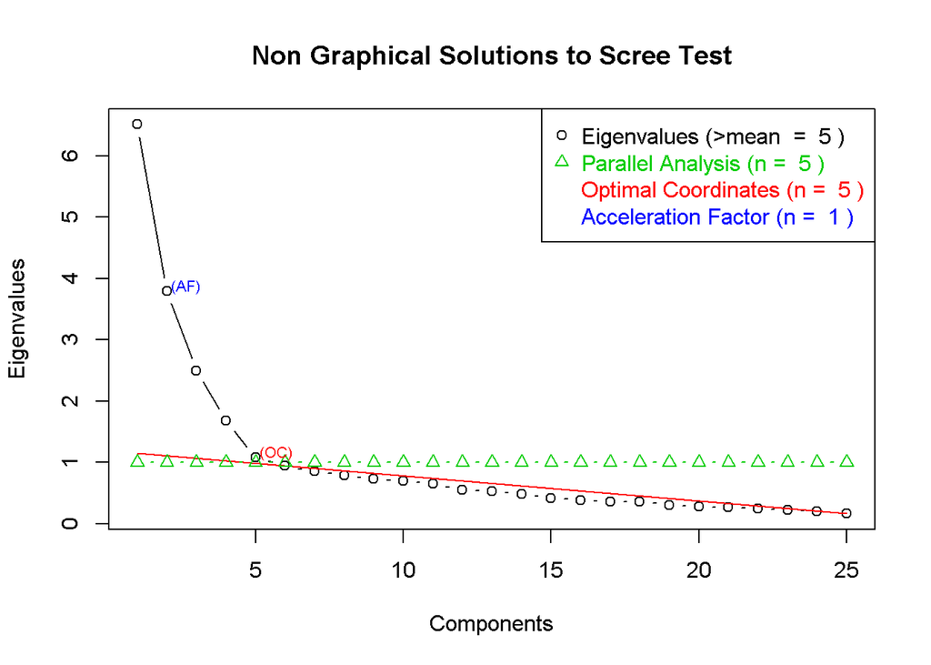

```r
#Eigen values
ev <- eigen(cor(cereal_fa)) # get eigenvalues
nS <- nScree(x=ev$values)
plotnScree(nS)
```

```r
#See how many factors have eigen value above 1
sum(numFactors$fa.values>1.0)
```

```
## [1] 3
```

```r
#See how many factors have eigen value above 0.79
sum(numFactors$fa.values>0.79)
```

```
## [1] 4
```

Factor the data and rotate it for optimized results.

```r
#Run factor analysis model with number of factors limit to 4 and no rotation
Factor <- factanal(cereal_fa, 4, rotation="none")
Factor
```

```
##
## Call:
## factanal(x = cereal_fa, factors = 4, rotation = "none")
##
## Uniquenesses:
##    Filling    Natural      Fibre      Sweet       Easy       Salt
##      0.444      0.388      0.312      0.353      0.846      0.511
## Satisfying     Energy        Fun       Kids      Soggy Economical
##      0.432      0.486      0.528      0.230      0.773      0.724
##     Health     Family   Calories      Plain      Crisp    Regular
##      0.224      0.348      0.591      0.551      0.680      0.588
##      Sugar      Fruit    Process    Quality      Treat     Boring
##      0.261      0.564      0.795      0.436      0.419      0.669
## Nutritious
##      0.268
##
## Loadings:
##            Factor1 Factor2 Factor3 Factor4
## Filling     0.697   0.218           0.121
## Natural     0.765  -0.127
## Fibre       0.759  -0.156   0.254   0.149
## Sweet               0.718   0.351
## Easy        0.290   0.209  -0.139
## Salt       -0.260   0.452   0.274   0.376
## Satisfying  0.679   0.303
## Energy      0.673   0.221   0.100
## Fun         0.289   0.562  -0.100  -0.248
## Kids        0.165   0.473  -0.710   0.125
## Soggy              -0.161  -0.181   0.409
## Economical  0.181  -0.112  -0.464   0.124
## Health      0.855  -0.191
## Family      0.261   0.404  -0.648
## Calories   -0.242   0.498   0.281   0.153
## Plain      -0.232  -0.332  -0.253   0.469
## Crisp       0.202   0.476          -0.210
## Regular     0.609           0.177
## Sugar      -0.349   0.642   0.403   0.205
## Fruit       0.328   0.201   0.491  -0.215
## Process    -0.333   0.211           0.213
## Quality     0.748
## Treat       0.370   0.598          -0.293
## Boring     -0.320  -0.308           0.361
## Nutritious  0.834           0.121   0.105
##
##                Factor1 Factor2 Factor3 Factor4
## SS loadings      6.016   3.318   2.112   1.132
## Proportion Var   0.241   0.133   0.084   0.045
## Cumulative Var   0.241   0.373   0.458   0.503
##
## Test of the hypothesis that 4 factors are sufficient.
## The chi square statistic is 398.19 on 206 degrees of freedom.
## The p-value is 2.3e-14
```

```r
print(Factor$loadings, digits=3, cutoff= .6, sort= TRUE)
```

```
##
## Loadings:
##            Factor1 Factor2 Factor3 Factor4
## Filling     0.697
## Natural     0.765
## Fibre       0.759
## Satisfying  0.679
## Energy      0.673
## Health      0.855
## Regular     0.609
## Quality     0.748
## Nutritious  0.834
## Sweet               0.718
## Fun
## Sugar               0.642
## Treat
## Kids                       -0.710
## Family                     -0.648
## Easy
## Salt
## Soggy
## Economical
## Calories
## Plain
## Crisp
## Fruit
## Process
## Boring
##
##                Factor1 Factor2 Factor3 Factor4
## SS loadings      6.016   3.318   2.112   1.132
## Proportion Var   0.241   0.133   0.084   0.045
## Cumulative Var   0.241   0.373   0.458   0.503
```

```r
#Run factanal again with varimax rotation this time
fa_promax<-factanal(cerealdata[,-1],4, rotation="promax",na.action = na.omit)
load<-fa_promax$loadings[,1:2]
print(fa_promax$loadings, digits = 3, cutoff = 0.4, sort = TRUE)
```

```
##
## Loadings:
##            Factor1 Factor2 Factor3 Factor4
## Filling     0.692
## Natural     0.779
## Fibre       0.896
## Satisfying  0.574
## Energy      0.625
## Health      0.859
## Regular     0.674
## Quality     0.614
## Nutritious  0.874
## Fun                 0.542
## Soggy              -0.549
## Plain              -0.724
## Treat               0.635
## Boring             -0.563
## Sweet                       0.695
## Salt                        0.732
## Calories                    0.601
## Sugar                       0.805
## Kids                                0.899
## Family                              0.796
## Easy
## Economical                          0.417
## Crisp               0.452
## Fruit               0.428
## Process
##
##                Factor1 Factor2 Factor3 Factor4
## SS loadings      5.225   2.509   2.460   2.290
## Proportion Var   0.209   0.100   0.098   0.092
## Cumulative Var   0.209   0.309   0.408   0.499
```

By observing the values in above table, the columns can be grouped as factors as below.

Filling, Natural, Fibre, Satisfying, Energy, Health, Regular, Quality, Nutritious Majority of these column names related to Health. So, this factor can be named as “Health”

Kids, Economical, Family  
Majority of these column names related to Family. So, this factor can be named as “Family”

Soggy, Plain, Crisp, Treat, Boring  
Majority of these column names related to Feelings. So, this factor can be named as “Feeling”

```r
#Check loadings
modelGPArotation<-fa(cerealdata[,-1],nfactors = 4,fm="ml", rotate="oblimin")
modelGPArotation$loadings
```

```
##
## Loadings:
##            ML1    ML2    ML3    ML4
## Filling     0.701  0.173  0.135
## Natural     0.763 -0.106
## Fibre       0.856        -0.165
## Sweet              0.714         0.221
## Easy        0.248         0.270
## Salt               0.732        -0.223
## Satisfying  0.607  0.125  0.315
## Energy      0.641  0.133  0.105  0.136
## Fun                0.111  0.319  0.501
## Kids                      0.883
## Soggy       0.151         0.174 -0.522
## Economical  0.102 -0.242  0.408 -0.211
## Health      0.839 -0.170
## Family                    0.788
## Calories           0.609
## Plain                     0.151 -0.686
## Crisp                     0.273  0.417
## Regular     0.654
## Sugar      -0.135  0.815
## Fruit       0.306  0.179 -0.350  0.410
## Process    -0.179  0.368        -0.179
## Quality     0.629 -0.178  0.106  0.148
## Treat       0.130  0.162  0.209  0.590
## Boring             0.119 -0.145 -0.533
## Nutritious  0.854
##
##                  ML1   ML2   ML3   ML4
## SS loadings    5.115 2.531 2.242 2.214
## Proportion Var 0.205 0.101 0.090 0.089
## Cumulative Var 0.205 0.306 0.396 0.484
```

```r
load<-modelGPArotation$loadings[,1:4]
load
```

```
##                     ML1         ML2          ML3          ML4
## Filling     0.701309046  0.17322694  0.135251852  0.057068721
## Natural     0.762630232 -0.10595635  0.004163596 -0.027007298
## Fibre       0.855949168  0.01858967 -0.164919309 -0.084931826
## Sweet       0.067773891  0.71424553  0.028029173  0.220888989
## Easy        0.247638121  0.08834512  0.270475596  0.009998621
## Salt        0.018487003  0.73211631  0.013617196 -0.223397402
## Satisfying  0.607278616  0.12478236  0.315196765  0.098436267
## Energy      0.641198914  0.13328900  0.104873055  0.136473431
## Fun         0.042685902  0.11102035  0.318878847  0.500673034
## Kids       -0.037378842  0.02764293  0.883482806 -0.022886870
## Soggy       0.151059001  0.09341945  0.174183279 -0.521699751
## Economical  0.102188330 -0.24153339  0.408176460 -0.211006299
## Health      0.838844472 -0.17020388 -0.038690068 -0.005738062
## Family      0.016740114 -0.07086225  0.787852445  0.078465067
## Calories   -0.090872130  0.60912744 -0.020082109  0.032502752
## Plain       0.004911829  0.01336992  0.151459553 -0.685571564
## Crisp      -0.005560806  0.09520097  0.273157527  0.416572496
## Regular     0.653515781  0.02391396 -0.085602665 -0.010412526
## Sugar      -0.135032147  0.81512934 -0.065420661  0.034845865
## Fruit       0.306033868  0.17938139 -0.349789614  0.410337098
## Process    -0.178563912  0.36792347  0.040530964 -0.179491090
## Quality     0.628917125 -0.17809305  0.105871812  0.147946115
## Treat       0.130110153  0.16203962  0.209314001  0.590304972
## Boring     -0.042978937  0.11926946 -0.145188923 -0.532883507
## Nutritious  0.853919890 -0.05081306 -0.022970503 -0.024900975
```

Group the factors and find average score for each factor.

```r
#Create the factors as per behaviour

#Filling,Natural,Fibre,Satisfying,Energy,Health,Regular,Quality,Nutritious
#Majority of these column names related to Health. So this factor can be named as "Health"
factor1 <- c(2,3,4,8,9,14,19,23,26)
```

```r
#Sweet,Salt,Calories,Sugar,Process
#Majority of these column names related to Taste. So this factor can be named as "Taste"
factor2 <- c(5,7,16,20,22)
```

```r
#Kids,Economical,Family
#Majority of these column names related to Family. So this factor can be named as "Family"
factor3 <- c(11,13,15)
```

```r
#Soggy,Plain,Crisp,Treat,Boring
#Majority of these column names related to Feelings. So this factor can be named as "Feeling"
factor4 <- c(12,17,18,24,25)
```

Create average. score for all 4 grouped factors

```r
cerealdata$factor1score <-apply(cerealdata[,factor1],1,mean)
cerealdata$factor2score <-apply(cerealdata[,factor2],1,mean)
cerealdata$factor3score <-apply(cerealdata[,factor3],1,mean)
cerealdata$factor4score <-apply(cerealdata[,factor4],1,mean)
```

Create new columns in the dataset and deduce the 12 brands aggregrate behavior for interpretation

```r
colnames(cerealdata)[27:30] <-c("Health", "Taste", "Family", "Feeling")
agg.fa.cereal<-aggregate(cerealdata[,27:30],  list(cerealdata[,1]), mean)
format(agg.fa.cereal, digits = 2)
```

```
##        Group.1 Health Taste Family Feeling
## 1      AllBran    3.9   2.2    3.0     2.2
## 2      CMuesli    4.0   2.8    3.5     2.2
## 3   CornFlakes    3.3   2.7    4.1     2.5
## 4    JustRight    3.6   2.7    3.2     2.3
## 5     Komplete    4.0   2.6    2.6     2.3
## 6   NutriGrain    3.4   3.1    4.0     2.6
## 7      PMuesli    4.1   2.9    3.2     2.5
## 8  RiceBubbles    2.9   2.2    4.2     2.6
## 9     SpecialK    3.5   2.3    3.7     2.5
## 10     Sustain    4.2   2.2    3.3     2.4
## 11    Vitabrit    3.9   1.9    3.9     2.5
## 12    Weetabix    3.9   2.1    3.8     2.4
```

Summarize the results.

```r
summary(agg.fa.cereal)
```

```
##        Group.1      Health          Taste           Family
##  AllBran   :1   Min.   :2.931   Min.   :1.920   Min.   :2.643
##  CMuesli   :1   1st Qu.:3.458   1st Qu.:2.185   1st Qu.:3.194
##  CornFlakes:1   Median :3.890   Median :2.462   Median :3.611
##  JustRight :1   Mean   :3.724   Mean   :2.468   Mean   :3.543
##  Komplete  :1   3rd Qu.:3.975   3rd Qu.:2.731   3rd Qu.:3.943
##  NutriGrain:1   Max.   :4.176   Max.   :3.100   Max.   :4.190
##  (Other)   :6
##     Feeling
##  Min.   :2.169
##  1st Qu.:2.321
##  Median :2.420
##  Mean   :2.410
##  3rd Qu.:2.521
##  Max.   :2.600
##
```